# Uso do R na Análise de Dados

Marcelo S. Perlin

Workshop GPDI (EA-UFRGS) - Junho/2019

# Agenda

- História e funcionalidades do R
- Por que escolher o R
- Como o R funciona
- Exemplo prático (*live coding*)

# Contexto

- Professor, pesquisador por +10 anos
- Experiência com diversos softwares (muito Matlab no passado)
- Experiência na produção e publicação de código aberto (+10 pacotes no CRAN)
- Usuário convicto do R desde 2014

Mais detalhes em https://www.msperlin.com/

# Meu livro

[figure not shown]

Ebook e versão impressa disponíveis na [Amazon](https://www.amazon.com.br/Processamento-An%C3%A1lise-Dados-Financeiros-Econ%C3%B4micos-ebook/dp/B07DN4M357/)

Versão online e gratuita, com os 7 primeiros capítulos, neste [link](https://www.msperlin.com/padfeR/).

Vídeos no Youtube [aqui](https://www.youtube.com/watch?v=CFd8O4f5bm4&list=PLO0YoYcxF6WFR1i45IRTnJ7-Xosrsx-Hl)

# O que é o R

**Definição**

O R é uma linguagem de programação criada em 1997, primeira versão publicada em 2000. Baseada na linguagem S, o R é voltado para a resolução de problemas estatísticos e visualização gráfica de dados;

**Autores**

**R**oss Ihaka e **R**obert Gentleman (*University of Auckland*);

**Funcionalidade**

R é conhecido pela sua facilidade e grande quantidade de módulos (pacotes) para resolver problemas relacionados ao ciclo de análise de dados (importação-reestruturação-análise-reporte);

**Custo**

**o R é totalmente gratuita e livre**, disponível em vários sistemas operacionais.

# Por que Escolher o R

- R é uma plataforma madura, estável, continuamente suportada e intensamente utilizada na indústria.
- Aprender a linguagem do R é fácil e viável, mesmo para aqueles sem experiência em programação.
- A interface do RStudio torna o uso da ferramenta bastante produtivo.
- Os pacotes do R permitem as mais diversas funcionalidades.
- O R tem compatibilidade com diferentes linguagens e sistemas operacionais.
- **O R é totalmente gratuito!**

# Usos do R

- Importação, exportação, tratamento e armazenamento de dados em arquivos locais ou da internet;
- Execução de diversas possibilidades de pesquisa empírica através da estimação de modelos econométricos e testes de hipóteses;
- Todo o ciclo de pesquisa é interno e natural ao R (**nunca mais formate tabelas no Excel!**);
- Organização de um processo automatizado de criação e divulgação de relatórios técnicos com o pacote `knitr` e a tecnologia *RMarkdown*;
- Escrita de um livro técnico com o `bookdown`;
- Produção de provas com conteúdo dinâmico (cada aluno com versão diferente de prova) – pacote `exams`;
- Criação e manutenção de websites estáticos com o `blogdown` ou dinâmicos com o `shiny`.

# Popularidade do R

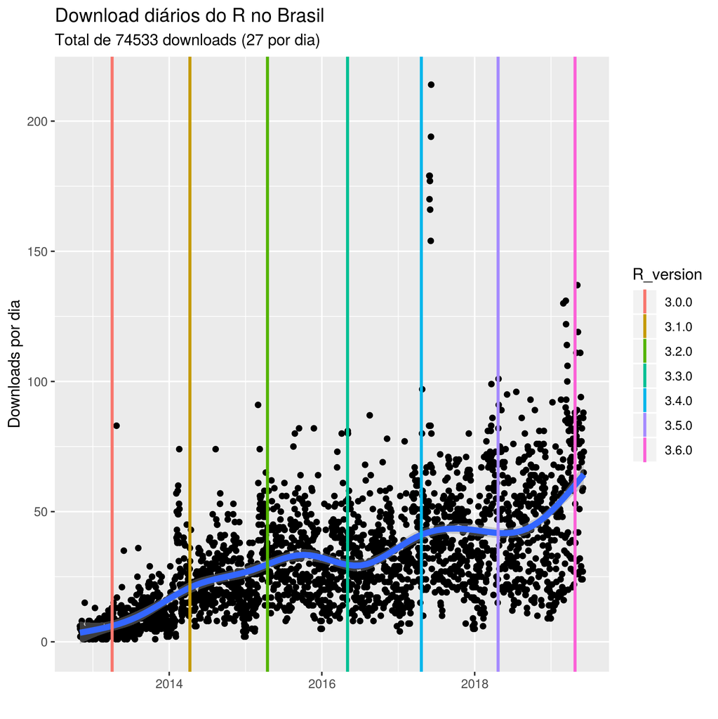

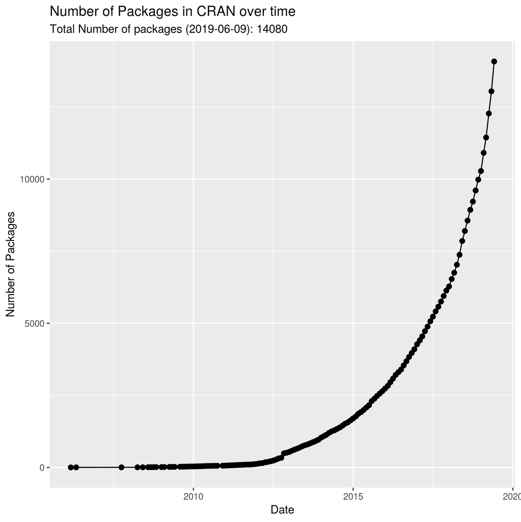

# Como o R funciona

A linguagem do R é o motor e a interface é o Rstudio.

- Instruções claras e precisas são definidas em um arquivo texto (*script*);
- Módulos são instalados e carregados via código;
- Dados são importados de arquivos locais (.xlsx, .csv, ..) ou da internet;
- Uma série de comandos em sequência faz a limpeza e manipulação dos dados;
- Saídas do programa na forma de tabelas, figuras ou qualquer outro objeto de interesse.

# Instalação do R e Rstudio

**R**

https://www.r-project.org/

**RStudio**

https://www.rstudio.com/

Também recomendo a instalação do Latex – *Miktex* (Windows) ou *texlive/mactex* (Linux/Mac):

**Latex**

http://miktex.org/download

https://www.tug.org/texlive/

http://www.tug.org/mactex/

# Exemplo prático

**Objetivo**

Analisar o resultado de investimento em 5 ações da B3, pros últimos 3 anos

**Saída 1**

Gráfico temporal dos preços ajustados para as 5 ações

**Saída 2**

Tabela com retorno total para o investidor